# Food Delivery Orders and Customer Behavior Analysis

Mayank Saini

2026-09-16

# 1. Introduction

Food delivery services have become an important part of the modern food and restaurant industry. Customers can order food from different restaurants through online delivery platforms, making it possible to analyze ordering patterns, food costs, delivery performance and customer satisfaction.

This project analyzes food delivery order data using R. The analysis focuses on order costs, delivery charges, preparation time, delivery time, customer ratings, cuisines, restaurants and order status.

Statistical analysis and data visualization techniques are used to identify patterns and relationships in the food delivery data.

# 2. Objectives

The main objectives of this project are:

- To import and understand the food delivery dataset.
- To examine the structure and characteristics of the data.
- To identify missing and duplicate values.
- To clean and preprocess the dataset.
- To analyze food and delivery costs.
- To analyze preparation and delivery times.
- To compare different cuisine types.
- To analyze restaurant performance.
- To study customer ratings.
- To analyze order status.
- To examine relationships between numerical variables.
- To create meaningful graphs and visualizations.
- To identify important findings and provide recommendations.

# 3. Data Importing

## Explanation of the R Code

The `read.csv()` function is used to import the food delivery CSV file into R. The imported dataset is stored in an object called `food_data`.

```r
# Load required package
library(ggplot2)

# Import the CSV dataset
food_data <- read.csv("food_delivery_orders.csv")

# Display the first six records
head(food_data)
```

```
##   Order_ID Customer_ID Restaurant_Name Cuisine_Type Food_Cost Delivery_Fee
## 1  ORD1001     CUST214  Spice Symphony       Indian       420           40
## 2  ORD1002     CUST305     Pizza Bella      Italian       550           50
## 3  ORD1003     CUST112      Dragon Wok      Chinese       310           30
## 4  ORD1004     CUST401     Taco Fiesta      Mexican       280           40
## 5  ORD1005     CUST223     Burger Barn     American       350           30
## 6  ORD1006     CUST189    Tokyo Treats     Japanese       680           60
##   Total_Order_Cost Prep_Time_Min Delivery_Time_Min Total_Delivery_Time
## 1              460            25                30                  55
## 2              600            20                25                  45
## 3              340            15                35                  50
## 4              320            18                22                  40
## 5              380            12                28                  40
## 6              740            30                25                  55
##   Order_Rating Order_Status
## 1          4.5    Delivered
## 2          4.8    Delivered
## 3          3.9    Delivered
## 4          4.2    Delivered
## 5          4.0    Delivered
## 6          4.9    Delivered
```

## Interpretation

The dataset has been successfully imported into R. The first six records are displayed to understand the type of information available in the dataset.

# 4. Understanding the Dataset

## 4.1 Number of Records

```r
cat("Number of records:", nrow(food_data))
```

```
## Number of records: 100
```

## 4.2 Number of Variables

```r
cat("Number of variables:", ncol(food_data))
```

```
## Number of variables: 12
```

## 4.3 Column Names

```r
names(food_data)
```

```
##  [1] "Order_ID"            "Customer_ID"         "Restaurant_Name"
##  [4] "Cuisine_Type"        "Food_Cost"           "Delivery_Fee"
##  [7] "Total_Order_Cost"    "Prep_Time_Min"       "Delivery_Time_Min"
## [10] "Total_Delivery_Time" "Order_Rating"        "Order_Status"
```

## 4.4 Dataset Structure

```r
str(food_data)
```

```
## 'data.frame':    100 obs. of  12 variables:
##  $ Order_ID           : chr  "ORD1001" "ORD1002" "ORD1003" "ORD1004" ...
##  $ Customer_ID        : chr  "CUST214" "CUST305" "CUST112" "CUST401" ...
##  $ Restaurant_Name    : chr  "Spice Symphony" "Pizza Bella" "Dragon Wok" "Taco Fiesta" ...
##  $ Cuisine_Type       : chr  "Indian" "Italian" "Chinese" "Mexican" ...
##  $ Food_Cost          : int  420 550 310 280 350 680 490 520 610 430 ...
##  $ Delivery_Fee       : int  40 50 30 40 30 60 40 50 50 40 ...
##  $ Total_Order_Cost   : int  460 600 340 320 380 740 530 570 660 470 ...
##  $ Prep_Time_Min      : int  25 20 15 18 12 30 22 25 35 18 ...
##  $ Delivery_Time_Min  : int  30 25 35 22 28 25 33 20 40 27 ...
##  $ Total_Delivery_Time: int  55 45 50 40 40 55 55 45 75 45 ...
##  $ Order_Rating       : num  4.5 4.8 3.9 4.2 4 4.9 4.1 4.6 3.5 4.4 ...
##  $ Order_Status       : chr  "Delivered" "Delivered" "Delivered" "Delivered" ...
```

## 4.5 Summary of Dataset

```r
summary(food_data)
```

```
##       Order_ID      Customer_ID   Restaurant_Name    Cuisine_Type
##  Length   :100   Length   :100   Length   :100    Length   :100
##  N.unique :100   N.unique :100   N.unique :  8    N.unique :  8
##  N.blank  :  0   N.blank  :  0   N.blank  :  0    N.blank  :  0
##  Min.nchar:  7   Min.nchar:  7   Min.nchar: 10    Min.nchar:  4
##  Max.nchar:  7   Max.nchar:  7   Max.nchar: 14    Max.nchar: 13
##
##    Food_Cost      Delivery_Fee  Total_Order_Cost Prep_Time_Min
##  Min.   :270.0   Min.   :30.0   Min.   :300.0    Min.   :10.00
##  1st Qu.:367.5   1st Qu.:40.0   1st Qu.:400.0    1st Qu.:17.00
##  Median :470.0   Median :40.0   Median :510.0    Median :21.00
##  Mean   :485.5   Mean   :43.2   Mean   :528.7    Mean   :21.71
##  3rd Qu.:560.0   3rd Qu.:50.0   3rd Qu.:610.0    3rd Qu.:26.00
##  Max.   :880.0   Max.   :70.0   Max.   :950.0    Max.   :36.00
##  Delivery_Time_Min Total_Delivery_Time  Order_Rating      Order_Status
##  Min.   :18.00     Min.   :30.00       Min.   :2.900   Length   :100
##  1st Qu.:25.00     1st Qu.:45.00       1st Qu.:4.000   N.unique :  1
##  Median :28.00     Median :50.00       Median :4.300   N.blank  :  0
##  Mean   :28.94     Mean   :50.65       Mean   :4.277   Min.nchar:  9
##  3rd Qu.:32.25     3rd Qu.:56.25       3rd Qu.:4.600   Max.nchar:  9
##  Max.   :48.00     Max.   :80.00       Max.   :4.900
```

## Explanation of the R Code

- `nrow()` counts the number of rows in the dataset.
- `ncol()` counts the number of columns.
- `names()` displays the variable names.
- `str()` shows the structure and data type of each variable.
- `summary()` provides descriptive information about the variables.

## Interpretation

The dataset contains information about food delivery orders, including customer details, restaurants, cuisine types, costs, preparation time, delivery time, ratings and order status.

# 5. Data Preprocessing and Cleaning

Data cleaning is an important step before statistical analysis. It helps ensure that the results are based on valid and consistent observations.

## 5.1 Check Missing Values

```r
missing_values <- colSums(is.na(food_data))

missing_values
```

```
##            Order_ID         Customer_ID     Restaurant_Name        Cuisine_Type
##                   0                   0                   0                   0
##           Food_Cost        Delivery_Fee    Total_Order_Cost       Prep_Time_Min
##                   0                   0                   0                   0
##   Delivery_Time_Min Total_Delivery_Time        Order_Rating        Order_Status
##                   0                   0                   0                   0
```

## Interpretation

The number of missing values is displayed for every variable. Variables with missing values can affect statistical calculations and therefore need to be considered during preprocessing.

## 5.2 Check Duplicate Records

```r
duplicate_count <- sum(duplicated(food_data))

cat("Number of duplicate records:", duplicate_count)
```

```
## Number of duplicate records: 0
```

## Interpretation

Duplicate records can result in the same order being counted more than once. The result above shows whether duplicate observations are present.

## 5.3 Check Data Types

```r
sapply(food_data, class)
```

```
##            Order_ID         Customer_ID     Restaurant_Name        Cuisine_Type
##         "character"         "character"         "character"         "character"
##           Food_Cost        Delivery_Fee    Total_Order_Cost       Prep_Time_Min
##           "integer"           "integer"           "integer"           "integer"
##   Delivery_Time_Min Total_Delivery_Time        Order_Rating        Order_Status
##           "integer"           "integer"           "numeric"         "character"
```

## 5.4 Check Unique Order Statuses

```r
unique(food_data$Order_Status)
```

```
## [1] "Delivered"
```

## 5.5 Check Unique Cuisine Types

```r
unique(food_data$Cuisine_Type)
```

```
## [1] "Indian"        "Italian"       "Chinese"       "Mexican"
## [5] "American"      "Japanese"      "Thai"          "Mediterranean"
```

# 6. Creating a Clean Dataset

```r
food_clean <- food_data

# Remove duplicate records
food_clean <- food_clean[!duplicated(food_clean), ]

# Remove rows with missing important numerical values
food_clean <- food_clean[
  !is.na(food_clean$Food_Cost) &
  !is.na(food_clean$Delivery_Fee) &
  !is.na(food_clean$Total_Order_Cost) &
  !is.na(food_clean$Prep_Time_Min) &
  !is.na(food_clean$Delivery_Time_Min) &
  !is.na(food_clean$Order_Rating),
]

# Keep positive cost and time values
food_clean <- food_clean[
  food_clean$Food_Cost >= 0 &
  food_clean$Delivery_Fee >= 0 &
  food_clean$Total_Order_Cost >= 0 &
  food_clean$Prep_Time_Min >= 0 &
  food_clean$Delivery_Time_Min >= 0,
]

cat("Original number of records:", nrow(food_data), "\n")
```

```
## Original number of records: 100
```

```r
cat("Records after cleaning:", nrow(food_clean), "\n")
```

```
## Records after cleaning: 100
```

```r
cat("Records removed:", nrow(food_data) - nrow(food_clean))
```

```
## Records removed: 0
```

## Explanation

The dataset is copied into `food_clean`. Duplicate observations are removed, followed by observations with missing important numerical values.

Negative values for costs and delivery times are also excluded because they are not meaningful for this analysis.

## Interpretation

The cleaned dataset contains valid observations that can be used for the remaining statistical analysis.

# 7. Basic Statistical Analysis

## 7.1 Food Cost Statistics

```r
food_cost_stats <- c(
  Mean = mean(food_clean$Food_Cost),
  Median = median(food_clean$Food_Cost),
  Minimum = min(food_clean$Food_Cost),
  Maximum = max(food_clean$Food_Cost),
  Standard_Deviation = sd(food_clean$Food_Cost)
)

food_cost_stats
```

```
##               Mean             Median            Minimum            Maximum
##           485.5000           470.0000           270.0000           880.0000
## Standard_Deviation
##           147.5824
```

## 7.2 Delivery Fee Statistics

```r
delivery_fee_stats <- c(
  Mean = mean(food_clean$Delivery_Fee),
  Median = median(food_clean$Delivery_Fee),
  Minimum = min(food_clean$Delivery_Fee),
  Maximum = max(food_clean$Delivery_Fee),
  Standard_Deviation = sd(food_clean$Delivery_Fee)
)

delivery_fee_stats
```

```
##               Mean             Median            Minimum            Maximum
##           43.20000           40.00000           30.00000           70.00000
## Standard_Deviation
##           10.52942
```

## 7.3 Total Order Cost Statistics

```r
order_cost_stats <- c(
  Mean = mean(food_clean$Total_Order_Cost),
  Median = median(food_clean$Total_Order_Cost),
  Minimum = min(food_clean$Total_Order_Cost),
  Maximum = max(food_clean$Total_Order_Cost),
  Standard_Deviation = sd(food_clean$Total_Order_Cost)
)

order_cost_stats
```

```
##               Mean             Median            Minimum            Maximum
##           528.7000           510.0000           300.0000           950.0000
## Standard_Deviation
##           157.6126
```

## Explanation

The `mean()` function calculates the average, `median()` calculates the middle value, `min()` and `max()` find the minimum and maximum values, and `sd()` calculates standard deviation.

## Interpretation

These statistics provide an overview of food costs, delivery charges and overall order costs in the dataset.

# 8. Order Status Analysis

```r
status_count <- table(food_clean$Order_Status)

status_count
```

```
##
## Delivered
##       100
```

## Order Status Visualization

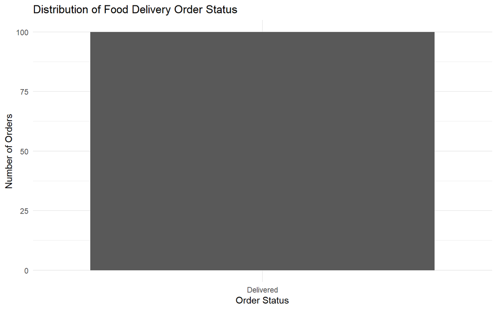

```r
status_data <- as.data.frame(status_count)

names(status_data) <- c("Order_Status", "Number_of_Orders")

ggplot(
  status_data,
  aes(x = Order_Status, y = Number_of_Orders)
) +
  geom_col() +
  labs(
    title = "Distribution of Food Delivery Order Status",
    x = "Order Status",
    y = "Number of Orders"
  ) +
  theme_minimal()
```

## Interpretation

The bar chart shows the number of orders belonging to each order status. This helps identify the proportion of orders that were successfully delivered and those that may have experienced another status.

# 9. Cuisine Type Analysis

```r
cuisine_count <- table(food_clean$Cuisine_Type)

cuisine_count
```

```
##
##      American       Chinese        Indian       Italian      Japanese
##            13            13            13            13            12
## Mediterranean       Mexican          Thai
##            12            12            12
```

## Cuisine Visualization

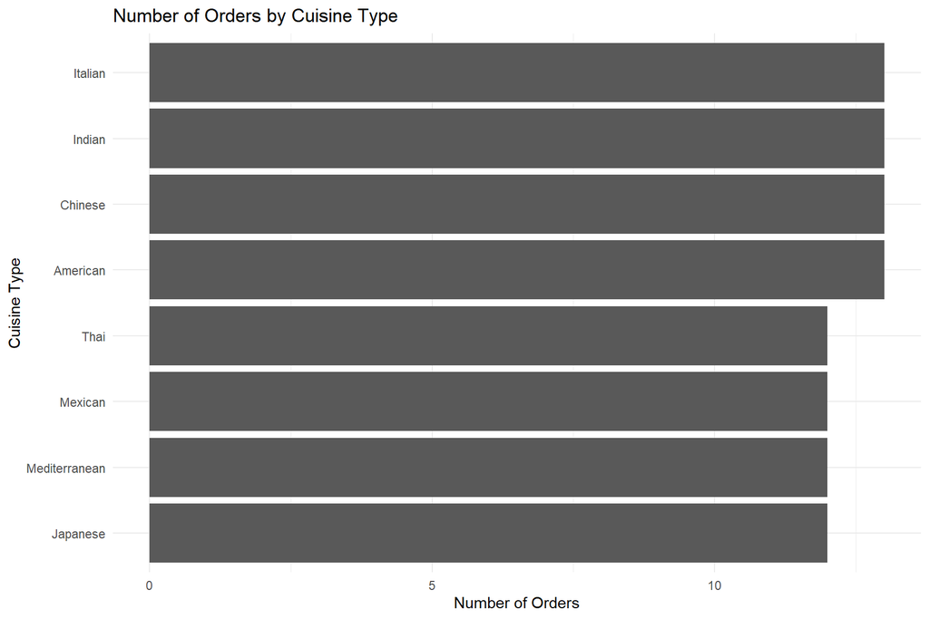

```r
cuisine_data <- as.data.frame(cuisine_count)

names(cuisine_data) <- c("Cuisine_Type", "Number_of_Orders")

ggplot(
  cuisine_data,
  aes(
    x = reorder(Cuisine_Type, Number_of_Orders),
    y = Number_of_Orders
  )
) +
  geom_col() +
  coord_flip() +
  labs(
    title = "Number of Orders by Cuisine Type",
    x = "Cuisine Type",
    y = "Number of Orders"
  ) +
  theme_minimal()
```

## Interpretation

The graph compares the popularity of different cuisine types based on the number of orders. Cuisine types with larger bars received more orders in the dataset.

# 10. Restaurant Analysis

## 10.1 Orders by Restaurant

```r
restaurant_count <- table(food_clean$Restaurant_Name)

restaurant_data <- as.data.frame(restaurant_count)

names(restaurant_data) <- c(
  "Restaurant_Name",
  "Number_of_Orders"
)

restaurant_data <- restaurant_data[
  order(-restaurant_data$Number_of_Orders),
]

head(restaurant_data, 10)
```

```
##   Restaurant_Name Number_of_Orders
## 1     Burger Barn               13
## 2      Dragon Wok               13
## 4     Pizza Bella               13
## 5  Spice Symphony               13
## 3     Olive Grove               12
## 6     Taco Fiesta               12
## 7   Thai Pavilion               12
## 8    Tokyo Treats               12
```

## 10.2 Top Restaurants

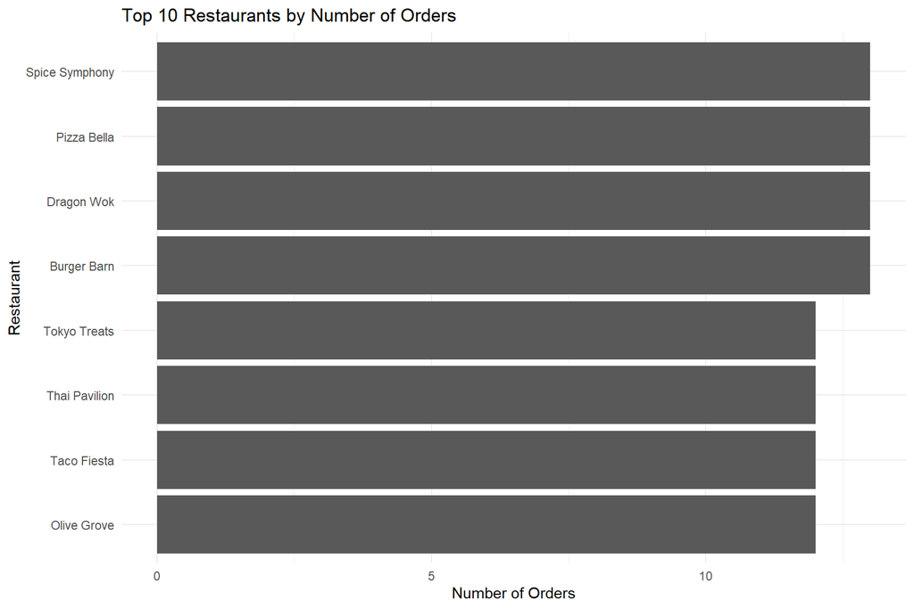

```r
top_restaurants <- head(restaurant_data, 10)

ggplot(
  top_restaurants,
  aes(
    x = reorder(Restaurant_Name, Number_of_Orders),
    y = Number_of_Orders
  )
) +
  geom_col() +
  coord_flip() +
  labs(
    title = "Top 10 Restaurants by Number of Orders",
    x = "Restaurant",
    y = "Number of Orders"
  ) +
  theme_minimal()
```

## Interpretation

The graph identifies the restaurants with the highest number of orders. This provides an indication of restaurant popularity within the dataset.

# 11. Food Cost Analysis

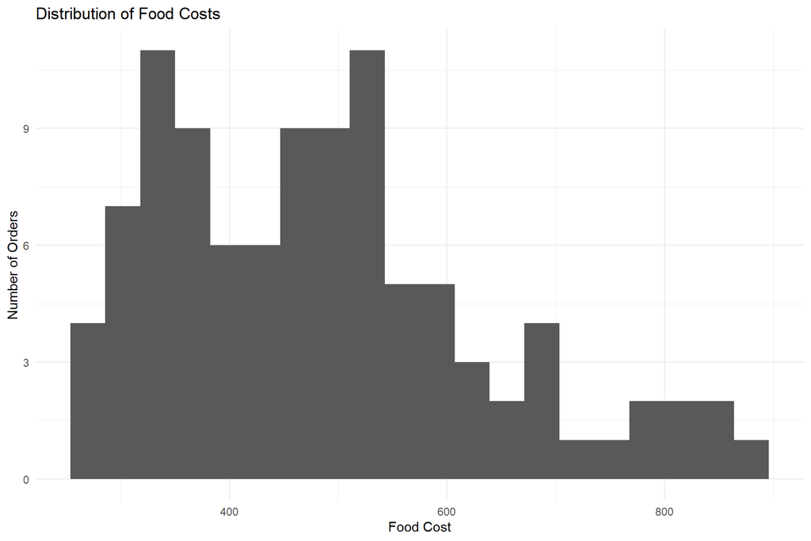

```r
ggplot(
  food_clean,
  aes(x = Food_Cost)
) +
  geom_histogram(bins = 20) +
  labs(
    title = "Distribution of Food Costs",
    x = "Food Cost",
    y = "Number of Orders"
  ) +
  theme_minimal()
```

## Interpretation

The histogram shows how food costs are distributed among the orders. It helps identify whether most orders are concentrated within a particular cost range.

# 12. Total Order Cost Analysis

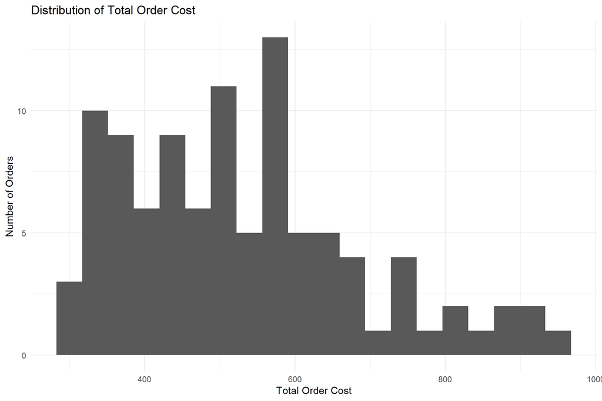

```r
ggplot(
  food_clean,
  aes(x = Total_Order_Cost)
) +
  geom_histogram(bins = 20) +
  labs(
    title = "Distribution of Total Order Cost",
    x = "Total Order Cost",
    y = "Number of Orders"
  ) +
  theme_minimal()
```

## Interpretation

The histogram displays the distribution of total spending per order. It provides an overview of customer spending patterns.

# 13. Delivery Time Analysis

## 13.1 Delivery Time Statistics

```r
delivery_time_stats <- c(
  Mean = mean(food_clean$Delivery_Time_Min),
  Median = median(food_clean$Delivery_Time_Min),
  Minimum = min(food_clean$Delivery_Time_Min),
  Maximum = max(food_clean$Delivery_Time_Min),
  Standard_Deviation = sd(food_clean$Delivery_Time_Min)
)

delivery_time_stats
```

```
##               Mean             Median            Minimum            Maximum
##          28.940000          28.000000          18.000000          48.000000
## Standard_Deviation
##           6.150996
```

## 13.2 Delivery Time Distribution

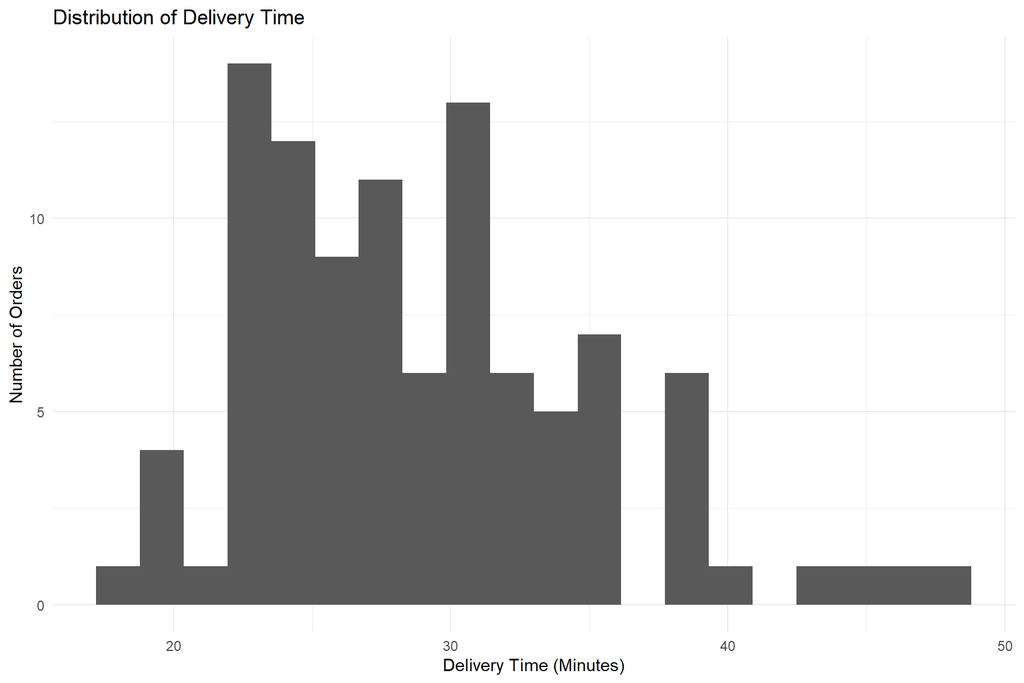

```r
ggplot(
  food_clean,
  aes(x = Delivery_Time_Min)
) +
  geom_histogram(bins = 20) +
  labs(
    title = "Distribution of Delivery Time",
    x = "Delivery Time (Minutes)",
    y = "Number of Orders"
  ) +
  theme_minimal()
```

## Interpretation

The delivery-time graph shows how long orders generally take to reach customers. It can help identify common delivery-time ranges and unusually long deliveries.

# 14. Food Preparation Time Analysis

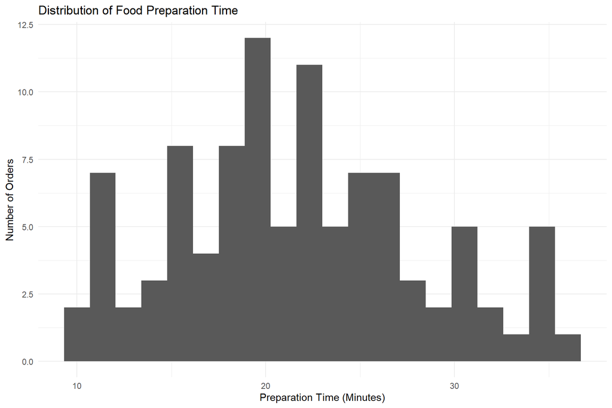

```r
ggplot(
  food_clean,
  aes(x = Prep_Time_Min)
) +
  geom_histogram(bins = 20) +
  labs(
    title = "Distribution of Food Preparation Time",
    x = "Preparation Time (Minutes)",
    y = "Number of Orders"
  ) +
  theme_minimal()
```

## Interpretation

The graph shows the distribution of food preparation times. Preparation time is an important factor that can contribute to the total time required to complete a food delivery order.

# 15. Customer Rating Analysis

## 15.1 Rating Distribution

```r
rating_count <- table(food_clean$Order_Rating)

rating_count
```

```
##
## 2.9   3 3.1 3.2 3.5 3.6 3.7 3.8 3.9   4 4.1 4.2 4.3 4.4 4.5 4.6 4.7 4.8 4.9
##   1   1   1   1   2   2   2   3   5   8   9   8   9   9  10   9   7   8   5
```

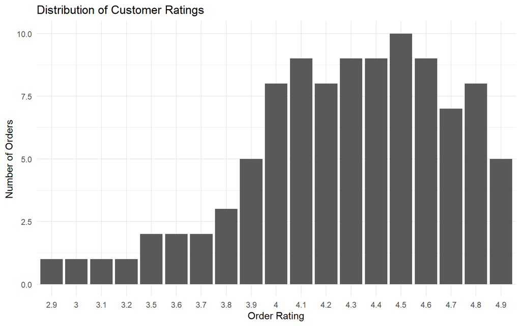

```r
rating_data <- as.data.frame(rating_count)

names(rating_data) <- c(
  "Order_Rating",
  "Number_of_Orders"
)

ggplot(
  rating_data,
  aes(
    x = factor(Order_Rating),
    y = Number_of_Orders
  )
) +
  geom_col() +
  labs(
    title = "Distribution of Customer Ratings",
    x = "Order Rating",
    y = "Number of Orders"
  ) +
  theme_minimal()
```

## 15.2 Average Rating

```r
average_rating <- mean(
  food_clean$Order_Rating,
  na.rm = TRUE
)

cat("Average customer rating:", round(average_rating, 2))
```

```
## Average customer rating: 4.28
```

## Interpretation

The rating distribution shows how customers evaluated their food delivery orders. The average rating provides an overall measure of customer satisfaction.

# 16. Customer Analysis

## Number of Unique Customers

```r
number_of_customers <- length(
  unique(food_clean$Customer_ID)
)

cat("Number of unique customers:", number_of_customers)
```

```
## Number of unique customers: 100
```

## Orders per Customer

```r
customer_orders <- table(food_clean$Customer_ID)

customer_orders <- sort(
  customer_orders,
  decreasing = TRUE
)

head(customer_orders, 10)
```

```
##
## CUST105 CUST109 CUST112 CUST114 CUST118 CUST121 CUST124 CUST127 CUST130 CUST134
##       1       1       1       1       1       1       1       1       1       1
```

## Interpretation

# 17. Total Order Cost by Cuisine

```r
cuisine_cost <- aggregate(
  Total_Order_Cost ~ Cuisine_Type,
  data = food_clean,
  FUN = mean
)

names(cuisine_cost)[2] <- "Average_Order_Cost"

cuisine_cost <- cuisine_cost[
  order(-cuisine_cost$Average_Order_Cost),
]

cuisine_cost
```

```
##    Cuisine_Type Average_Order_Cost
## 5      Japanese           839.1667
## 3        Indian           601.5385
## 8          Thai           568.3333
## 4       Italian           566.1538
## 6 Mediterranean           536.6667
## 7       Mexican           389.1667
## 2       Chinese           373.8462
## 1      American           371.5385
```

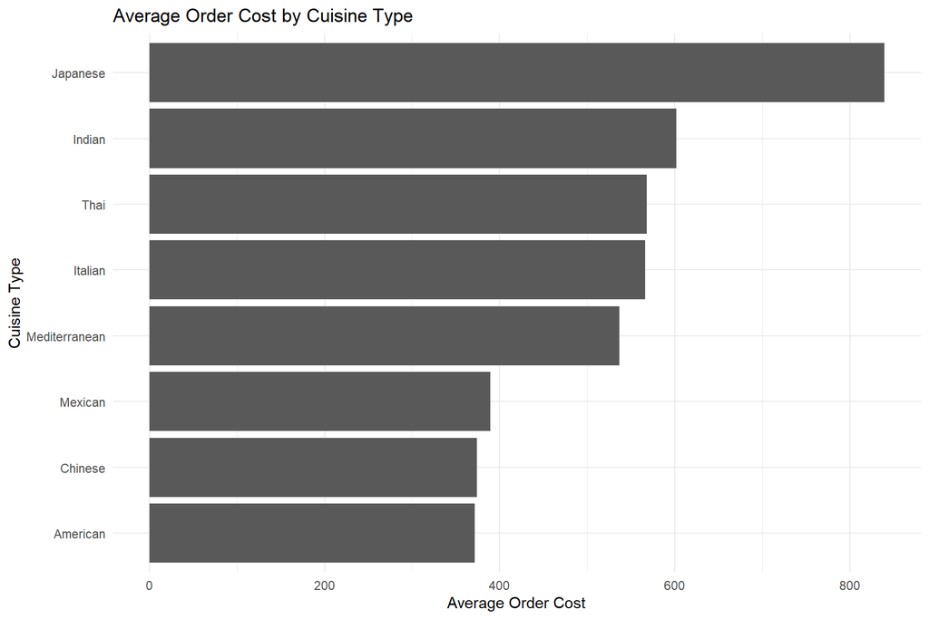

```r
ggplot(
  cuisine_cost,
  aes(
    x = reorder(Cuisine_Type, Average_Order_Cost),
    y = Average_Order_Cost
  )
) +
  geom_col() +
  coord_flip() +
  labs(
    title = "Average Order Cost by Cuisine Type",
    x = "Cuisine Type",
    y = "Average Order Cost"
  ) +
  theme_minimal()
```

## Interpretation

The graph compares average spending across different cuisine types. This can help identify cuisines associated with higher or lower average order values.

# 18. Delivery Time and Customer Rating

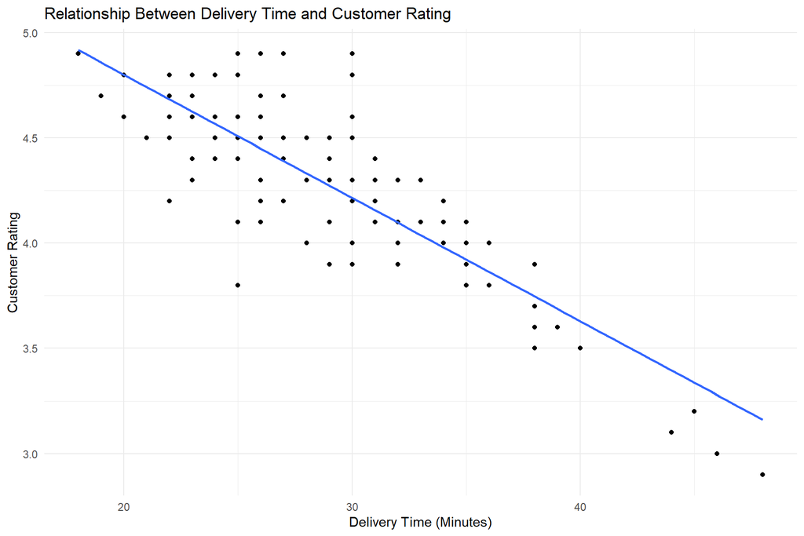

```r
ggplot(
  food_clean,
  aes(
    x = Delivery_Time_Min,
    y = Order_Rating
  )
) +
  geom_point() +
  geom_smooth(
    method = "lm",
    se = FALSE
  ) +
  labs(
    title = "Relationship Between Delivery Time and Customer Rating",
    x = "Delivery Time (Minutes)",
    y = "Customer Rating"
  ) +
  theme_minimal()
```

## Interpretation

The scatter plot examines whether delivery time is associated with customer ratings. The trend line provides a simple visual indication of the direction of the relationship.

A relationship in the graph should not automatically be interpreted as causation.

# 19. Food Cost and Total Order Cost

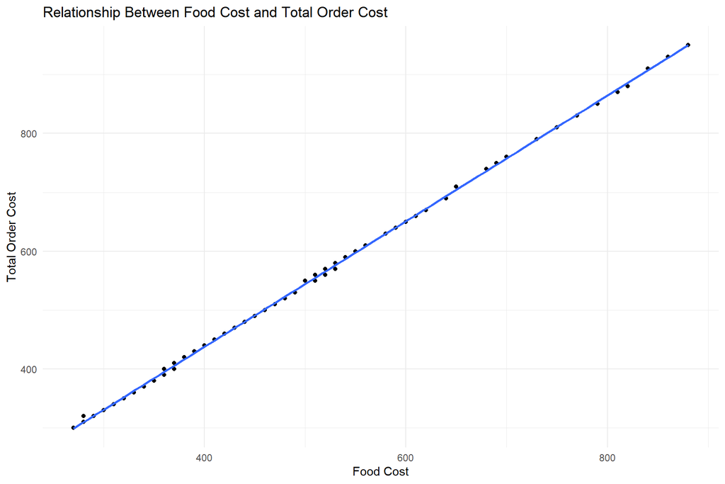

```r
ggplot(
  food_clean,
  aes(
    x = Food_Cost,
    y = Total_Order_Cost
  )
) +
  geom_point() +
  geom_smooth(
    method = "lm",
    se = FALSE
  ) +
  labs(
    title = "Relationship Between Food Cost and Total Order Cost",
    x = "Food Cost",
    y = "Total Order Cost"
  ) +
  theme_minimal()
```

## Interpretation

The graph examines the relationship between the food cost and the final order cost. Since food cost is an important component of the total order cost, a positive relationship may be expected.

# 20. Correlation Analysis

Correlation measures the strength and direction of a linear relationship between numerical variables.

```r
correlation_data <- food_clean[
  ,
  c(
    "Food_Cost",
    "Delivery_Fee",
    "Total_Order_Cost",
    "Prep_Time_Min",
    "Delivery_Time_Min",
    "Order_Rating"
  )
]

correlation_matrix <- cor(
  correlation_data,
  use = "complete.obs"
)

round(correlation_matrix, 3)
```

```
##                   Food_Cost Delivery_Fee Total_Order_Cost Prep_Time_Min
## Food_Cost             1.000        0.949            1.000         0.895
## Delivery_Fee          0.949        1.000            0.956         0.868
## Total_Order_Cost      1.000        0.956            1.000         0.896
## Prep_Time_Min         0.895        0.868            0.896         1.000
## Delivery_Time_Min     0.260        0.256            0.260         0.514
## Order_Rating          0.120        0.095            0.118        -0.177
##                   Delivery_Time_Min Order_Rating
## Food_Cost                     0.260        0.120
## Delivery_Fee                  0.256        0.095
## Total_Order_Cost              0.260        0.118
## Prep_Time_Min                 0.514       -0.177
## Delivery_Time_Min             1.000       -0.841
## Order_Rating                 -0.841        1.000
```

## Explanation

The `cor()` function calculates correlation coefficients.

Correlation values range from -1 to +1:

- A value close to +1 indicates a strong positive relationship.
- A value close to -1 indicates a strong negative relationship.
- A value close to 0 indicates a weak linear relationship.

## Interpretation

The correlation matrix helps identify relationships among food cost, delivery fee, total order cost, preparation time, delivery time and customer ratings.

# 21. Total Delivery Time Analysis

The total delivery time represents the complete time involved in preparation and delivery.

```r
total_delivery_stats <- c(
  Mean = mean(food_clean$Total_Delivery_Time),
  Median = median(food_clean$Total_Delivery_Time),
  Minimum = min(food_clean$Total_Delivery_Time),
  Maximum = max(food_clean$Total_Delivery_Time),
  Standard_Deviation = sd(food_clean$Total_Delivery_Time)
)

total_delivery_stats
```

```
##               Mean             Median            Minimum            Maximum
##           50.65000           50.00000           30.00000           80.00000
## Standard_Deviation
##           10.97874
```

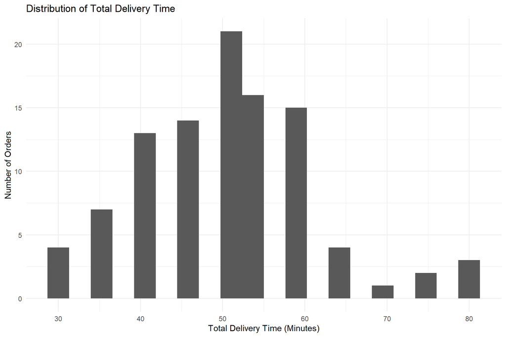

```r
ggplot(
  food_clean,
  aes(x = Total_Delivery_Time)
) +
  geom_histogram(bins = 20) +
  labs(
    title = "Distribution of Total Delivery Time",
    x = "Total Delivery Time (Minutes)",
    y = "Number of Orders"
  ) +
  theme_minimal()
```

## Interpretation

The graph shows the distribution of total time required to prepare and deliver orders. This is useful for understanding overall delivery efficiency.

# 22. Overall Project Summary

```r
overall_summary <- data.frame(
  Total_Orders = nrow(food_clean),
  Unique_Customers = length(unique(food_clean$Customer_ID)),
  Unique_Restaurants = length(unique(food_clean$Restaurant_Name)),
  Unique_Cuisines = length(unique(food_clean$Cuisine_Type)),
  Average_Food_Cost = mean(food_clean$Food_Cost),
  Average_Delivery_Fee = mean(food_clean$Delivery_Fee),
  Average_Order_Cost = mean(food_clean$Total_Order_Cost),
  Average_Delivery_Time = mean(food_clean$Delivery_Time_Min),
  Average_Rating = mean(food_clean$Order_Rating)
)

overall_summary
```

```
##   Total_Orders Unique_Customers Unique_Restaurants Unique_Cuisines
## 1          100              100                  8               8
##   Average_Food_Cost Average_Delivery_Fee Average_Order_Cost
## 1             485.5                 43.2              528.7
##   Average_Delivery_Time Average_Rating
## 1                 28.94          4.277
```

# 23. Findings

# 24. Business Recommendations

Based on the analysis, the following recommendations can be considered:

- Restaurants should monitor preparation times to improve delivery efficiency.
- Delivery services should identify orders with unusually long delivery times.
- Restaurants can study popular cuisine categories to understand customer demand.
- Customer ratings can be used to identify areas requiring service improvement.
- Restaurants can analyze average order values to understand customer spending behavior.
- Delivery charges should be monitored to maintain a balance between customer satisfaction and operational costs.

# 25. Conclusion

This project analyzed food delivery order data using R.

The analysis included data importing, preprocessing, data cleaning, descriptive statistics, order analysis, cuisine analysis, restaurant analysis, cost analysis, delivery-time analysis, customer rating analysis, customer analysis and correlation analysis.

Various graphs were created to visualize important patterns and relationships within the dataset. Statistical measures were used to summarize the data and support the interpretation of results.

Overall, the project demonstrates how R can be used for practical data analysis and visualization in the food delivery industry. The results can help understand customer behavior, restaurant demand, order costs and delivery performance.

# 26. Explanation of R Functions Used

| R Function | Purpose |
| --- | --- |
| `read.csv()` | Imports CSV data |
| `head()` | Displays first records |
| `nrow()` | Counts rows |
| `ncol()` | Counts columns |
| `names()` | Displays column names |
| `str()` | Shows dataset structure |
| `summary()` | Provides summary statistics |
| `is.na()` | Identifies missing values |
| `duplicated()` | Identifies duplicate records |
| `unique()` | Finds unique values |
| `table()` | Creates frequency tables |
| `mean()` | Calculates average |
| `median()` | Calculates median |
| `min()` | Finds minimum |
| `max()` | Finds maximum |
| `sd()` | Calculates standard deviation |
| `aggregate()` | Calculates grouped statistics |
| `cor()` | Calculates correlation |
| `ggplot()` | Creates visualizations |
| `geom_col()` | Creates bar charts |
| `geom_histogram()` | Creates histograms |
| `geom_point()` | Creates scatter plots |
| `geom_smooth()` | Adds a trend line |
| `theme_minimal()` | Applies a clean graph theme |

# 27. References

1. R Core Team. R: A Language and Environment for Statistical Computing.
2. Posit. RStudio IDE Documentation.
3. Food Delivery Orders dataset used for this project.